# Ejericios Ejemplo

## 2.1 Problema 1

A continuación, verán una línea de texto que dice “R Markdown Cheat Sheet”. Hagan que ese texto sea un hipervínculo a la siguiente dirección: https://rstudio.com/wp-content/uploads/2015/02/rmarkdown-cheatsheet.pdf. Cuando Previsualicen este archivo, debería poder hacer clic en el enlace y lo llevarán a un sitio web útil.

[R Markdown Cheat Sheet](https://rstudio.com/wp-content/uploads/2015/02/rmarkdown-cheatsheet.pdf)

## 2.2 Problema 2

Agreguen su nombre como autor/a de este documento. Hay una forma “oficial” de hacerlo utilizando el encabezado YAML.[YAML Headers in R Markdown](https://bookdown.org/yihui/rmarkdown/html-document.html).

## 2.3 Problema 3

Utilicen la sección YAML de este documento para agregar una tabla de contenidos. La tabla de contenidos (toc) se generará automáticamente cuando Previsualicen el documento. Tengan en cuenta que la indentación es importante. Además, observen que la tabla de contenidos debe estar “anidada” debajo de la línea html_notebook:.

## 2.4 Problema 4

Una vez que vean aparecer una tabla de contenidos en la parte superior de este documento cuando Previsualicen, agreguen una opción adicional al encabezado YAML para que la tabla de contenidos “flote”. Una de las páginas de tutoriales vinculadas anteriormente pueden ayudarles.

## 2.5 Problema 5

Vayan aquí:[R Markdown Themes Gallery](https://www.datadreaming.org/post/r-markdown-theme-gallery/) y elijan un tema “preempaquetado” que se vea bien. Luego, apliquen ese tema a este documento agregando:

theme: nombre_del_tema

en su encabezado YAML.

## 2.6 Problema 6

El nivel del encabezado para este problema es incorrecto. El texto “Problema 6” es una sub-sub-sub-sección. Debería ser una sub-sección para que coincida con los encabezados de las otras subsecciones de los problemas. Corrijan el nivel de este encabezado.

## 2.7 Problema 7

Hagan que el siguiente texto aparezca de la forma descrita:

*Hagan que este texto aparezca en cursiva.*

**Hagan que este texto aparezca en negrita.**

- Hagan de este texto una lista con viñetas.
1. Hagan de este texto una lista numerada.

```r
"Hagan que este texto aparezca como 'código en línea'."
```

```
## [1] "Hagan que este texto aparezca como 'código en línea'."
```

# 3 Aprendiendo R

Muy bien. Ahora están listos para empezar con R. R es un lenguaje de programación ampliamente utilizado en la computación científica. Tiene funciones integradas para matemáticas, álgebra, estadística y muchas cosas más. Aprender R les permitirá poner experiencia en programación de computadoras en sus currículum vitae. Muchos puestos de analista y ciencia de datos esperan que los candidatos de la maravillosa Universidad San Francisco tengan experiencia en R.

## 3.1 Problema 8

A continuación, se presenta un fragmento de código de R. Contiene un comentario. Los comentarios no son código. Son texto que colocas dentro del código de R para ayudar a describir las cosas. Comienzas un comentario en R usando un signo numeral. Todo lo que está después del signo de numeral es ignorado por R. Solo está allí para ayudarles a ustedes y a otros usuarios a entender su código.

```r
# Este es 1 comentario.
## Aqui voy a poner un numero 1.
1
```

```
## [1] 1
```

```r
### Me salio el numero 1
# Todo después del # es un comentario.
# comentario
# Los pinguinos tienen rodillas?
```

Agreguen un comentario más al fragmento de código anterior. Puede decir cualquier cosa que quieran.

## 3.2 Problema 9

Agreguen un comentario al siguiente fragmento de código. Su comentario debe decir “Los comentarios son muy importantes porque nos ayudan a comprender el código de la computadora”.

```r
# Los comentarios son muy importantes porque nos ayudan a comprender el código de la computadora
```

## 3.3 Problema 10

A continuación, hagan su propio fragmento de código de R (chunk). Pueden usar el botón “Insertar” en la parte superior de esta ventana o simplemente puedes escribir las tres marcas de acento (`), {r,}, (`). Asegúren terminar su fragmento de código agregando otras tres marcas de acento debajo de tus primeras tres. La tecla de la marca de acento está en la esquina superior izquierda del teclado, junto a la tecla 1 y encima de Tab. Dentro de su fragmento de código, agreguen un comentario que diga “Este es mi fragmento de código”.

```r
# Este es mi fragmento de codigo
```

## 3.4 Problema 11

Ahora vamos a intentar hacer algo de matemáticas. Hagan un chunk para averiguar cuánto es 3487634 + 4237634.

```r
3487634 + 4237634
```

```
## [1] 7725268
```

## 3.5 Problema 12

Podemos utilizar variables en R. Una variable es una representación nombrada de un valor. Ejecuten el ejemplo de código a continuación (usando la flecha verde en la esquina superior derecha del bloque). Estamos usando <- para “almacenar” el valor dentro de la variable. Este símbolo representa una flecha que apunta hacia la izquierda. Llamamos a esto un “operador de asignación” porque asigna un valor.

```r
a <- 34
b <- 2378
c <- a + b

print(c)
```

```
## [1] 2412
```

¿Cuál creen que es el valor de a? Escriban su respuesta aquí: 34 ¿Cuál creen que es el valor de b? Escriban su respuesta aquí: 2378 ¿Cuál creen que es el valor de c? Escriban su respuesta aquí: 2412

## 3.6 Problema 13

Podemos pedirle a R que “imprima” el valor de una variable en la pantalla. Podemos utilizar la función print() para ver los valores de las variables. Por ejemplo, usemos el botón verde de flecha (ejecutar) para ver cuál es el valor de a:

```r
# Este es un comentario.
# A continuación, se encuentra una "llamada" a la función print()
# Al incluir a dentro de los paréntesis, estamos diciéndole a R qué imprimir.
print(a)
```

```
## [1] 34
```

Ponemos dentro de los paréntesis para decirle a R qué queremos imprimir. R sabe automáticamente cómo imprimir variables. Cuando R ve print(a), nos mostrará el valor de a.

## 3.7 Problema 14

Ahora, pueden crear un solo bloque de código en R debajo y úsenlo para imprimir los valores de b y c. Después de escribir su bloque de código y sus declaraciones de impresión, usen la flecha verde para ejecutar el código.

```r
print(b)
```

```
## [1] 2378
```

```r
print(c)
```

```
## [1] 2412
```

## 3.8 Problema 15

Las variables pueden ser números o cadenas de texto. “Cadena de texto” es lo que llamamos texto en la programación informática. En R, indicamos que algo es una cadena de texto (o una cadena de caracteres) envolviéndola entre comillas. Puedes usar comillas simples ’ ’ o comillas dobles ” “. R las trata de la misma manera.

```r
mi_cadena <- "Esta es una cadena de texto."
```

En el bloque de código siguiente, utilicen la función print() para mostrar el valor de mi_cadena.

```r
# Usen print() para mostrar el valor de mi_cadena.
print(mi_cadena)
```

```
## [1] "Esta es una cadena de texto."
```

Una nota sobre las variables en RStudio

Pueden ver sus variables y sus valores en la esquina superior derecha de RStudio. En esta esquina, hay cuatro pestañas: “Entorno”, “Historial”, “Conexiones” y “Presentación”. Todas las variables activas en su sesión de R se muestran en la pestaña “Entorno”.

## 3.9 Problema 16

R puede hacer todo tipo de matemáticas. Para comenzar, existen cuatro operaciones algebráicas fundamentales:

suma (+) resta (-) multiplicación (*) división (/)

Pueden usar las cuatro operaciones en R. A continuación, por favor creen una nueva variable llamada solución y almacenen en ella el valor de la siguiente ecuación: 5*(1+1)-3. Ejecuten el fragmento de código cuando haya terminado.

```r
solucion <- 5* (1+1)-3
print(solucion)
```

```
## [1] 7
```

## 3.10 Problema 17

R viene con muchas otras funciones matemáticas también. Por ejemplo:

raíz cuadrada (‘sqrt()’) logaritmo natural (‘log’) exponentes (‘^’) seno (‘sin()’)

A continuación, hice el cálculo la raíz cuadrada de 5 al cuadrado. Noten que puede concatenar operaciones tal como las escribiría en un papel.

```r
sqrt(5^2)
```

```
## [1] 5
```

A continuación, primero calculen el logaritmo natural de 10, luego eleven ese valor al tercer poder:

```r
log(10)^3
```

```
## [1] 12.20807
```

## 3.11 Problema 18

R tiene funciones de ayuda integradas. Para acceder a la página de ayuda de una función, escriban ? seguido del nombre de la función. Luego, ejecuten esa línea de código (o fragmento de código). La documentación de ayuda aparecerá en la ventana inferior derecha. A continuación, por favor ejecuten el fragmento de código y miren la ventana de documentación a la derecha.

```r
?print
```

Escriban el título de la página de ayuda que apareció:Print Values

## 3.12 Problema 19

¿Cuál es la raíz cuadrada del logaritmo natural de 10? Calculen una respuesta usando R.

```r
sqrt(log(10))
```

```
## [1] 1.517427
```

## 3.13 Problema 20

Un “directorio de trabajo” es lo que llamamos la carpeta de la computadora en la que estamos trabajando actualmente. R siempre tiene un directorio de trabajo. Para ver en qué carpeta está trabajando actualmente, usen la función getwd(). Si abren R Studio haciendo doble clic en un archivo R, entonces el directorio de trabajo actual debería ser cualquier carpeta en la que esté ese archivo R. Usen esta función en un fragmento de código a continuación para mostrar su directorio de trabajo actual:

```r
getwd()
```

```
## [1] "/Users/sebasgranizo/Downloads"
```

A veces, es posible que deseen cambiar su directorio de trabajo. Por ejemplo, es posible que deseen almacenar todas sus tareas y datos en la misma carpeta de su computadora. Pueden cambiar su directorio de trabajo usando setwd(). El setwd() les permite cambiar su directorio de trabajo actual. Usen getwd(…) para imprimir el directorio de trabajo actual.

```r
setwd("/Users/sebasgranizo/Downloads")
getwd()
```

```
## [1] "/Users/sebasgranizo/Downloads"
```

## 3.14 Problema 21

En matemáticas, a menudo utilizamos vectores y matrices de números. También podemos usar vectores y matrices en R. Para definir un vector de valores, utilizamos la función c(). En el bloque de código de abajo, creen un vector y una nueva matriz y guárdenlos en las variables vector1 y matrix1. Luego, impriman los valores de ambas variables. Su vector debe tener 5 elementos. Su matriz debe tener 2 x 3 elementos (filas x columnas). Es posible que Google les ayude. :)

```r
vector1 <- c(1,2,3,4,5,6)
matrix1 <- matrix(vector1, nrow = 2, ncol = 3,byrow = TRUE)
print(vector1)
```

```
## [1] 1 2 3 4 5 6
```

```r
print(matrix1)
```

```
##      [,1] [,2] [,3]
## [1,]    1    2    3
## [2,]    4    5    6
```

## 3.15 Problema 22

Ahora, creen un nuevo bloque de código y muestren la transposición de matrix1.(Les puse la función de respuesta)

```r
t(matrix1)
```

```
##      [,1] [,2]
## [1,]    1    4
## [2,]    2    5
## [3,]    3    6
```

## 3.16 Problema 23

En R, pueden usar la lógica para comparar valores. A continuación se muestra una lista de operadores lógicos y sus descripciones:

igual a == mayor que > menor que < mayor o igual que >= menor o igual que <= no igual a !=

Usando cada operador lógico en la lista anterior solo una vez, cambien los operadores lógicos en las declaraciones a continuación para que todas las siguientes declaraciones impriman FALSE. En este momento, todas son TRUE.

```r
print("Apple" != "Apple")
```

```
## [1] FALSE
```

```r
print(TRUE == FALSE)
```

```
## [1] FALSE
```

```r
print(2 > 10)
```

```
## [1] FALSE
```

```r
print(-1 < -3)
```

```
## [1] FALSE
```

```r
print(4 < 4)
```

```
## [1] FALSE
```

```r
print(5 > 7)
```

```
## [1] FALSE
```

## 3.17 Problema 24

También podemos reasignar variables. Primero, creemos algunas variables:

```r
x <- 0
y <- 100
z <- x + y
```

Tenemos tres nuevas variables: x, y y z, iguales a 0, 100 y 100, respectivamente. Usen el bloque de código a continuación para reasignar x a 5.

```r
x <- 5
```

Finalmente, impriman los valores de x, y y z.

```r
print(x)
```

```
## [1] 5
```

```r
print(y)
```

```
## [1] 100
```

```r
print(z)
```

```
## [1] 100
```

## 3.18 Problema 25

R viene con algunos conjuntos de datos integrados. Pueden ver una lista de ellos ejecutando el comando data(). Uno de esos conjuntos de datos, llamado cars, se carga automáticamente para su conveniencia. Los conjuntos de datos en R se llaman “dataframes”. Un dataframe es como una hoja de cálculo de Excel. Tiene columnas que representan variables y filas que representan las unidades u observaciones. Usando Google, encuentren una función que puedan usar para producir un resumen simple del conjunto de datos cars. Impriman ese resumen con el bloque de código a continuación.

```r
summary(cars)
```

```
##      speed           dist
##  Min.   : 4.0   Min.   :  2.00
##  1st Qu.:12.0   1st Qu.: 26.00
##  Median :15.0   Median : 36.00
##  Mean   :15.4   Mean   : 42.98
##  3rd Qu.:19.0   3rd Qu.: 56.00
##  Max.   :25.0   Max.   :120.00
```

## 3.19 Problema 26

¿Qué representan las columnas de cars? ¿Cuáles son sus valores medios?

## 3.20 Problema 27

Pueden acceder a una sola columna de un dataframe con el símbolo del signo de dólar. Por ejemplo, cars$speed hace referencia a la columna de velocidades en el dataframe cars. Si quisiéramos calcular el valor medio para esta columna, podríamos simplemente ejecutar mean(cars$speed).

A continuación, calculen la velocidad mediana para los autos en el dataframe cars.

```r
mean(cars$speed)
```

```
## [1] 15.4
```

## 3.21 Problema 28

La columna de velocidad en cars está en millas por hora (mph). La columna de distancia (dist) está en millas. Si usamos la fórmula (velocidad = millas / hora) y conocemos la velocidad y las millas, podemos resolver para horas. En otras palabras, sabemos qué tan rápido va cada automóvil y sabemos qué tan lejos han ido. Agreguen una nueva columna al dataframe cars llamada cars$hours que nos indique cuánto tiempo debe haber conducido cada automóvil. Esto requiere varios pasos. Veámoslos:

## 3.22 Problema 28a.

Primero, resuelvan velocidad = (millas / hora) para horas.

```r
horas <- cars$dist/cars$speed

print(horas)
```

```
##  [1] 0.5000000 2.5000000 0.5714286 3.1428571 2.0000000 1.1111111 1.8000000
##  [8] 2.6000000 3.4000000 1.5454545 2.5454545 1.1666667 1.6666667 2.0000000
## [15] 2.3333333 2.0000000 2.6153846 2.6153846 3.5384615 1.8571429 2.5714286
## [22] 4.2857143 5.7142857 1.3333333 1.7333333 3.6000000 2.0000000 2.5000000
## [29] 1.8823529 2.3529412 2.9411765 2.3333333 3.1111111 4.2222222 4.6666667
## [36] 1.8947368 2.4210526 3.5789474 1.6000000 2.4000000 2.6000000 2.8000000
## [43] 3.2000000 3.0000000 2.3478261 2.9166667 3.8333333 3.8750000 5.0000000
## [50] 3.4000000
```

## 3.23 Problema 28b.

A continuación, creen una nueva variable llamada hours utilizando nuestras operaciones algebraicas en cars$speed y cars$dist. Pueden tratar estas columnas exactamente como variables únicas antes. Debido a que las columnas tienen la misma longitud, R sabrá que debe realizar las operaciones que se usan en cada fila de datos.

```r
hours <- horas
```

## 3.24 Problema 28c.

Si lo hemos hecho correctamente, será una lista (vector) de números. Un número para cada automóvil en nuestro conjunto de datos. A continuación, utilicen la función print para imprimir nuestra variable llamada hours.

```r
print(hours)
```

```
##  [1] 0.5000000 2.5000000 0.5714286 3.1428571 2.0000000 1.1111111 1.8000000
##  [8] 2.6000000 3.4000000 1.5454545 2.5454545 1.1666667 1.6666667 2.0000000
## [15] 2.3333333 2.0000000 2.6153846 2.6153846 3.5384615 1.8571429 2.5714286
## [22] 4.2857143 5.7142857 1.3333333 1.7333333 3.6000000 2.0000000 2.5000000
## [29] 1.8823529 2.3529412 2.9411765 2.3333333 3.1111111 4.2222222 4.6666667
## [36] 1.8947368 2.4210526 3.5789474 1.6000000 2.4000000 2.6000000 2.8000000
## [43] 3.2000000 3.0000000 2.3478261 2.9166667 3.8333333 3.8750000 5.0000000
## [50] 3.4000000
```

## 3.25 Problema 28d.

Ahora queremos agregar nuestra nueva variable como una columna en el dataframe cars. Podemos tratar las columnas de un dataframe como vectores. Para agregar una nueva columna, podemos utilizar el mismo operador de asignación <- que utilizamos anteriormente. A continuación, utilice una línea de código para asignar la variable hours a una nueva columna del dataframe llamada cars$hours.

```r
cars$hours <- hours
```

## 3.26 Problema 28e

Finalmente, utilicen los mismos comandos print y summary que descubrieron anteriormente para resumir el dataframe cars nuevo y mejorado.

```r
summary(cars)
```

```
##      speed           dist            hours
##  Min.   : 4.0   Min.   :  2.00   Min.   :0.500
##  1st Qu.:12.0   1st Qu.: 26.00   1st Qu.:1.921
##  Median :15.0   Median : 36.00   Median :2.523
##  Mean   :15.4   Mean   : 42.98   Mean   :2.632
##  3rd Qu.:19.0   3rd Qu.: 56.00   3rd Qu.:3.186
##  Max.   :25.0   Max.   :120.00   Max.   :5.714
```

```r
print(cars)
```

```
##    speed dist     hours
## 1      4    2 0.5000000
## 2      4   10 2.5000000
## 3      7    4 0.5714286
## 4      7   22 3.1428571
## 5      8   16 2.0000000
## 6      9   10 1.1111111
## 7     10   18 1.8000000
## 8     10   26 2.6000000
## 9     10   34 3.4000000
## 10    11   17 1.5454545
## 11    11   28 2.5454545
## 12    12   14 1.1666667
## 13    12   20 1.6666667
## 14    12   24 2.0000000
```

[output cut: 36 more lines]

## 3.27 Problema 29

Podemos utilizar la función plot() para trazar todos los pares de variables en nuestro dataframe. “Pasamos” nuestro dataframe cars a la función plot() a continuación. Llamamos “pasar” a un argumento cuando colocamos variables o valores dentro de los paréntesis de una función. Estamos “pasando” el dataframe cars a la función plot().

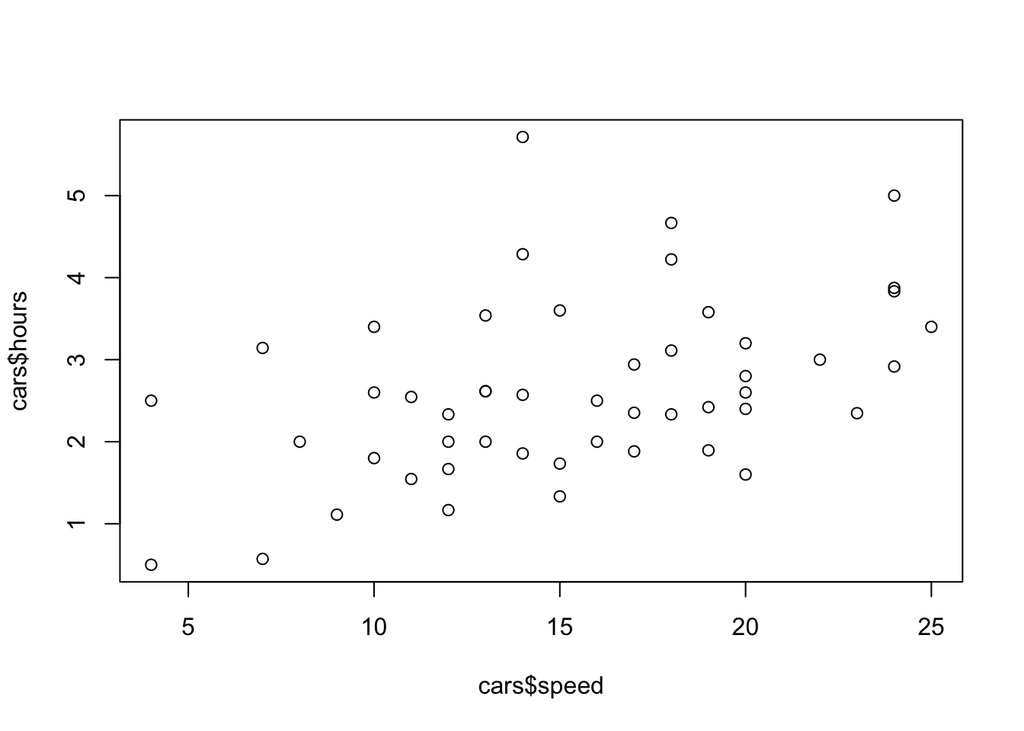

```r
plot(x=cars$speed, y=cars$hours)
```

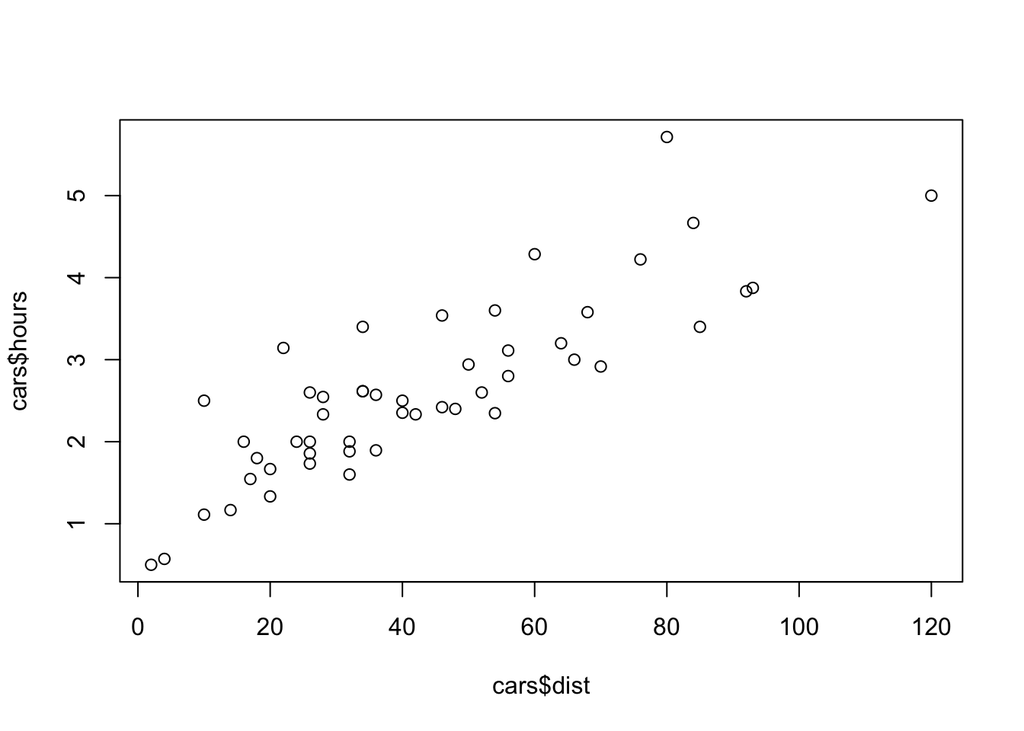

```r
plot(x=cars$dist, y=cars$hours)
```

## 3.28 Problema 30

En pocas palabras, describan las relaciones mostradas entre speed, dist y hours en las gráficas.

Minetras aumenta la velocidad, el tiempo varia, pero mientras que la distancia sube, el tiempo sube de igual manera.

## 3.29 Problema 31

¿Ven? R es HERMOSO!!!!

Ahora, usen el menú desplegable al lado de Preview en la parte superior de esta ventana para Tejer a HTML. Renombren su archivo 01_SUNOMBRE.html y pueden enviarlo por correo. No ofrezco revisar todos los trabajos, pero podemos revisar las preguntas en la clase del próximo jueves.

Abrazo.